# Lab7

Byoungwook Jang

March 20th, 2018

### Exercises

- Create a function which, given a numeric vector, outputs a standardized vector (zero mean, standard deviation one)
- Set your seed to 100. Generate 20 Gaussians from $N(20, 2)$ and $N(18,2)$ each. Perform a two-sample t-test with null hypothesis $\mu_1 = \mu_2$ with equal variance assumption. Do you reject the null?

## Density function of normal distributions

In R, functions are a symbolic representation of an operation to be carried out on variables known as inputs. Functions are useful when you plan to apply a certain operation to a range of inputs which are cumbersome to be declared beforehand. The syntax for declaring a function can be best understood with an example:

The probability density of a normal distribution $N(\mu,\sigma^{2})$ is defined as

$$f(x) = \frac{1}{\sqrt{2 \pi \sigma^2}} \exp\{-\frac{(x - \mu)^2}{2 \sigma^2}\}\,.$$

There is a function `dnorm()` in R that can produce values of this density. Now without using that function, write your own function to calculate $f(x)$. Then plot the densities of $N(0,1)$ from your own function on a grid of 30 points from $-3$ to $3$, and compare with the result using the internal function `dnorm()`.

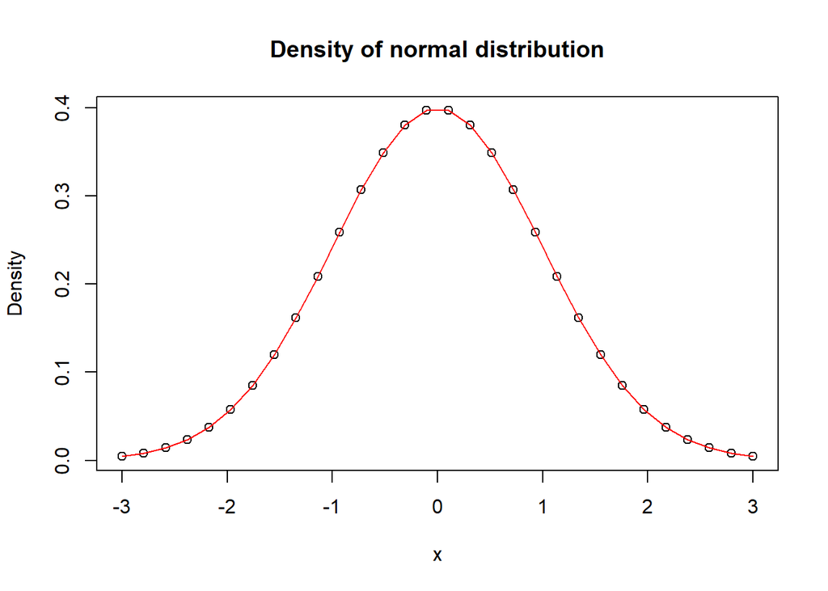

The return statement within a function is used when you want some value returned by the function.

Remember the variables defined inside a function are local and not accessible to the outside. More on this in the [Environment](http://adv-r.had.co.nz/Environments.html) section of [Advanced R](http://adv-r.had.co.nz/).

## Coin flipping game

In a fair coin flipping game, let $B_{1},B_{2},\ldots$ denote the result where $B_{i}=1$ if it’s heads and $0$ if it’s tails. Let $N$ be the number of experiments when the first time you get heads, i.e.
$$N = \min \{n \geq 1: B_{n}=1\}\,.$$
Suppose you are given a number $m$, write a piece of R code that runs the game for $m$ times and prints $N_{1},\ldots,N_{m}$.

Hint: you can use the command `rbinom(1,1,0.5)` to simulate the result of flipping a coin. The function `rbinom(n, size, prob)` generates binomial random variable.

```
## [1] 1
## [1] 1
## [1] 2
## [1] 2
## [1] 1
## [1] 1
## [1] 1
## [1] 2
## [1] 1
## [1] 4
```

## Another coin flipping game

In a fair coin flipping game, two players A and B bet on the result of the first two consecutives that has the same face. If the first two consecutive are heads, then A wins. If the first two consecutive are tails, then B wins.

Suppose you are given a number $m$, write a piece of R code that simulates the game for $m$ times and prints the winner at each time. And calculate the proportion of times that A wins.

```
## [1] "B wins"
## [1] "B wins"
## [1] "B wins"
## [1] "A wins"
## [1] "A wins"
## [1] "B wins"
## [1] "A wins"
## [1] "B wins"
## [1] "A wins"
## [1] "B wins"
## [1] "A wins"
## [1] "B wins"
## [1] "A wins"
## [1] "B wins"
## [1] "B wins"
```

[output cut: 85 more lines]